# Alliances Analysis

## Analysis Process

```r
library(ggplot2)
library(grid)
library(gridExtra)
library(tidyr)
library(dplyr)
library(viridis)
library(oce)
library(vcd)
library(vcdExtra)
library(extracat)
## Set file path
path = "/Users/cynthiaclement/Desktop"
################################# Looking at US Alliances #################################
dyad_al= read.csv("./data/version4.1_csv/alliance_v4.1_by_dyad.csv", sep= ",")
dyad_al_year = read.csv("./data/version4.1_csv/alliance_v4.1_by_dyad_yearly.csv", sep= ",")
member_alliances = read.csv("./data/version4.1_csv/alliance_v4.1_by_member.csv", sep= ",")
member_al_year = read.csv("./data/version4.1_csv/alliance_v4.1_by_member_yearly.csv", sep= ",")
dir_al_year= read.csv("./data/version4.1_csv/alliance_v4.1_by_directed_yearly.csv", sep= ",")
dir_al= read.csv("./data/version4.1_csv/alliance_v4.1_by_directed.csv", sep= ",")
d=data.frame(x1=c(1914,1939, 1947, 1950, 1955, 2001), x2=c(1918, 1945, 1991, 1953, 1975, 2010), Conflict=c("WWI", "WWII", "Cold War", "Korean War", "Vietnam War", "Afghanistan War"), r=c(1,2,3,4,5,6))
mylables <- c("No War" , "WWI", "WWII", "Cold War", "Korean War", "Vietnam War", "Afghanistan War")
```

```r
dayd_al_year <- filter(dyad_al_year, dyad_al_year$year %in% c(1900:2012))
dyad_al_year$length = dyad_al_year$dyad_end_year - dyad_al_year$dyad_st_year
dayd_al_year$conflict <- "0"
dyad_al_year$count <- 1
dir_alliances <- gather(dir_al_year, treaty_type, idicator, defense:entente)
dir_alliances <- dir_alliances[!dir_alliances$idicator %in%  0,]
dir_alliances$dyad_end_year[dir_alliances$dyad_end_year %in% NA] = 2016
dir_alliances <- dir_alliances[dir_alliances$year>1900,]
alliance_count <- dir_alliances[, c(2,3,14,16)]
alliance_count$count <- 1
gp_ct <- aggregate(cbind(count) ~ ccode1+state_name1+year+treaty_type, data =alliance_count, FUN = sum )
gp_ct$Conflict <- "0"
for(i in c(1:length(d$x1))){
  gp_ct[gp_ct$year >= d$x1[i] & gp_ct$year <= d$x2[i], length(gp_ct)] <- as.character(i)
}
```

WWI was triggered by the assassination of the Archduke Franz Ferdinand of Austria. His death set off diplomatic crisis as countries that were not involved in the original conflict has to get involved. Once Austria declared war on Serbia for the death of the Arch Duke, Russia had to step into defend Serbia. Once Russia entered the conflict, Germany was forced to enter the conflict due to its alliance with Austria. When German invaded Belgium, Great Britain had to mobilize due to their alliance. This pattern continued to eventually involve all the major powers of the world for a devastating battle. Such alliances were the cause of World War I. Since then the number of Alliances has only grown and continues to grow. For this reason, we wanted to look at alliances and see how they change during wars.

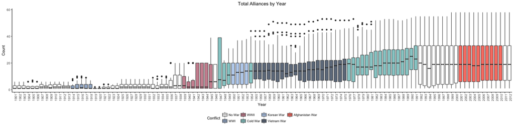

```r
ggplot() +
  xlab("Year") +
  ylab("Count")+
  geom_boxplot(data = gp_ct, aes(x = as.factor(year), y = count, fill = Conflict)) +
  ggtitle("Total Alliances by Year") +
  theme_classic()+
  theme(plot.title = element_text(hjust = .5), axis.text.x = element_text(angle = 90), legend.position="bottom")+
  scale_fill_manual(values=c("white", "lightsteelblue3", "pink3", "paleturquoise3", "lightsteelblue2", "lightsteelblue4","salmon" ), labels = mylables)
```

Next we looked at the types of alliances formed during this time. The COW data reports on 4 types of alliances: defense, neutrality, entente and non-aggression. In a defense alliance the member states agree to defend one or more states in the event of conflict. With a neutrality alliance there is an agreement to maintain neutrality towards the members of the alliance. In non-aggression the members agree to take no military action against one another. With an entente alliance there is an understanding that the state would consult with one or more states in the alliance if a crisis occurred

The plots below show the number of alliances by alliance type. The top row shows the number of alliances that were formed each year and the second row shows number of alliances that were terminated that year.

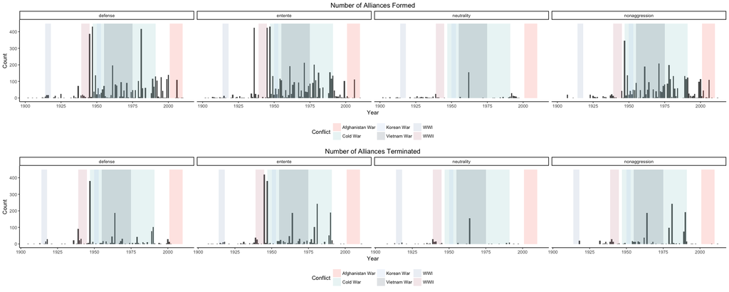

```r
dir_al_0 <- filter(dir_al, dir_al$dyad_st_year %in% c(1900:2012))
all_st <- gather(dir_al_0, treaty_type, idicator, defense:entente)
all_st <- all_st[!all_st$idicator %in%  0,]
all_st$dyad_end_year[all_st$dyad_end_year %in% NA] = 2016
al_st_count <- all_st[, c(3,5,8,11,15)]
al_st_count$count <- 1
gp_st <- aggregate(cbind(count) ~ dyad_st_year+treaty_type, data =al_st_count, FUN = sum )
a <- ggplot() +
  xlab("Year") +
  ylab("Count")+
  geom_bar(data = al_st_count, aes(x = dyad_st_year)) +
  ggtitle("Total Alliances by Year they started")+
  geom_rect(data=d, mapping=aes(xmin=x1, xmax=x2, ymin=0, ymax=max(450), fill=Conflict),alpha=0.2)+
  ggtitle("Number of Alliances Formed") +
  theme_classic()+
  theme(legend.position="bottom", plot.title = element_text(hjust = .5)) +
  scale_fill_manual(values=c("salmon", "paleturquoise3", "lightsteelblue2", "lightsteelblue4", "lightsteelblue3", "pink3")) + facet_wrap(~treaty_type, nrow = 1 )
b<- ggplot() +
  xlab("Year") +
  ylab("Count")+
  geom_bar(data = al_st_count[al_st_count$dyad_end_year < 2016, ], aes(x = dyad_end_year)) +
  ggtitle("Number of Alliances Terminated")+
  geom_rect(data=d, mapping=aes(xmin=x1, xmax=x2, ymin=0, ymax=max(450), fill=Conflict),alpha=0.2)+
  theme_classic()+
  theme(legend.position="bottom", plot.title = element_text(hjust = .5)) +
  scale_fill_manual(values=c("salmon", "paleturquoise3", "lightsteelblue2", "lightsteelblue4", "lightsteelblue3", "pink3")) + facet_wrap(~treaty_type, nrow = 1)
grid.arrange(a,b, nrow =2)
```

It is clear that most of the alliances formed were at the end of WWII and during the Cold War. Also the most frequently formed alliances were defense and entente. Surprisingly, most alliances also ended around the same time. To dig in further to get a better understand of what types of treaties were formed and why they ended, we looked at individual countries.

**United States of America**

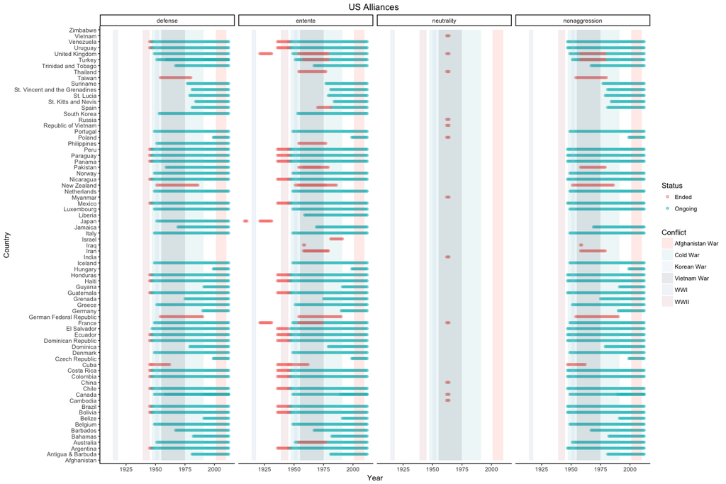

```r
al_us_yr <- filter(dir_al_year, dir_al_year$state_name1 %in% "United States of America")
al_us_yr <- gather(al_us_yr, Treaty, idicator, defense:entente)
al_us_yr <- al_us_yr[!al_us_yr$idicator %in%  0,]
al_us_yr$dyad_end_year[al_us_yr$dyad_end_year %in% NA] = 2016
al_us_yr <- al_us_yr[, c(5,8,11,14,16)]
al_us_yr$count = 1
al_us_yr$Status <- ""
al_us_yr$Status[al_us_yr$dyad_end_year < 2012] <- "Ended"
al_us_yr$Status[al_us_yr$dyad_end_year== 2012] <- "Ongoing"
ggplot() +
  xlab("Year") +
  ylab("Country")+
  geom_point(data =al_us_yr, aes(x=year, y = state_name2, color =Status), alpha = .5) +
  geom_rect(data=d, mapping=aes(xmin=x1, xmax=x2, ymin="Afghanistan", ymax="Zimbabwe", fill=Conflict),alpha=0.15) +
  ggtitle("US Alliances ")+
  theme_classic()+
  scale_fill_manual(values=c("salmon", "paleturquoise3", "lightsteelblue2", "lightsteelblue4", "lightsteelblue3", "pink3")) + facet_wrap(~treaty_type, nrow = 1)+
  facet_wrap(~Treaty, nrow = 1 ) +
  theme(legend.position="right", plot.title = element_text(hjust = .5))
```

**United Kingdom**

[figure not shown]

```r
dir_al_year2 <- filter(dir_al_year, dir_al_year$dyad_st_year %in% c(1900:2016))
al_gb_yr <- filter(dir_al_year2, dir_al_year2$state_name1 %in% c("United Kingdom"))
al_gb_yr <- gather(al_gb_yr, Treaty, idicator, defense:entente)
al_gb_yr <- al_gb_yr[!al_gb_yr$idicator %in%  0,]
al_gb_yr <- al_gb_yr[, c(3,5,8,11,14,16)]
al_gb_yr$count = 1
al_gb_yr$Status[al_gb_yr$dyad_end_year < 2012] <- "Ended"
al_gb_yr$Status[al_gb_yr$dyad_end_year== 2012] <- "Ongoing"
ggplot() +
  xlab("Year") +
  ylab("Country")+
  geom_point(data =al_us_yr, aes(x=year, y = state_name2, color =Status), alpha = .5) +
  geom_rect(data=d, mapping=aes(xmin=x1, xmax=x2, ymin="Afghanistan", ymax="Zimbabwe", fill=Conflict),alpha=0.15) +
  ggtitle("United Kingdom Alliances")+
  theme_classic()+
  scale_fill_manual(values=c("salmon", "paleturquoise3", "lightsteelblue2", "lightsteelblue4", "lightsteelblue3", "pink3")) + facet_wrap(~treaty_type, nrow = 1)+
  facet_wrap(~Treaty, nrow = 1 ) +
  theme(legend.position="right", plot.title = element_text(hjust = .5))
```

**Germany**

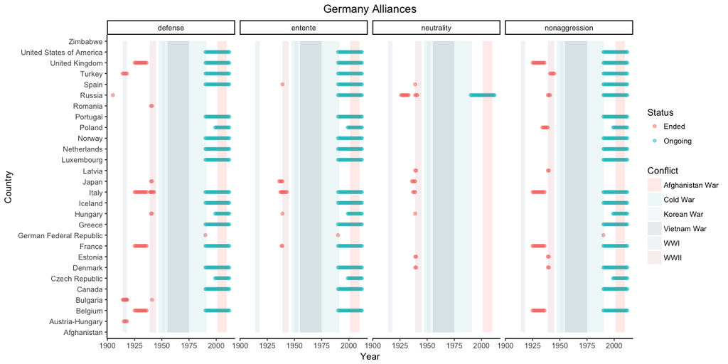

```r
al_gmy_yr <- filter(dir_al_year2, dir_al_year2$state_name1 %in% c("Germany"))
al_gmy_yr <- gather(al_gmy_yr, Treaty, idicator, defense:entente)
al_gmy_yr <- al_gmy_yr[!al_gmy_yr$idicator %in%  0,]
al_gmy_yr <- al_gmy_yr[, c(5,8,11,14,16)]
al_gmy_yr$count = 1
al_gmy_yr$Status[al_gmy_yr$dyad_end_year < 2012] <- "Ended"
al_gmy_yr$Status[al_gmy_yr$dyad_end_year== 2012] <- "Ongoing"
ggplot() +
  xlab("Year") +
  ylab("Country")+
  geom_point(data =al_gmy_yr, aes(x=year, y = state_name2, color =Status), alpha = .5) +
  geom_rect(data=d, mapping=aes(xmin=x1, xmax=x2, ymin="Afghanistan", ymax="Zimbabwe", fill=Conflict),alpha=0.15) +
  ggtitle("Germany Alliances")+
  theme_classic()+
  scale_fill_manual(values=c("salmon", "paleturquoise3", "lightsteelblue2", "lightsteelblue4", "lightsteelblue3", "pink3")) + facet_wrap(~treaty_type, nrow = 1)+
  facet_wrap(~Treaty, nrow = 1 ) +
  theme(legend.position="right", plot.title = element_text(hjust = .5))
```

**Russia**

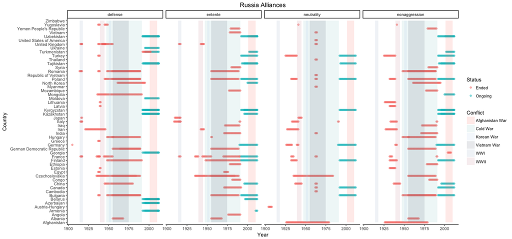

```r
al_rus_yr <- filter(dir_al_year2, dir_al_year2$state_name1 %in% c("Russia"))
al_rus_yr <- gather(al_rus_yr, Treaty, idicator, defense:entente)
al_rus_yr <- al_rus_yr[!al_rus_yr$idicator %in%  0,]
al_rus_yr <- al_rus_yr[, c(5,8,11,14,16)]
al_rus_yr$count = 1
al_rus_yr$Status[al_rus_yr$dyad_end_year < 2012] <- "Ended"
al_rus_yr$Status[al_rus_yr$dyad_end_year== 2012] <- "Ongoing"
ggplot() +
  xlab("Year") +
  ylab("Country")+
  geom_point(data =al_rus_yr, aes(x=year, y = state_name2, color =Status), alpha = .5) +
  geom_rect(data=d, mapping=aes(xmin=x1, xmax=x2, ymin="Afghanistan", ymax="Zimbabwe", fill=Conflict),alpha=0.15) +
  ggtitle("Russia Alliances")+
  theme_classic()+
  scale_fill_manual(values=c("salmon", "paleturquoise3", "lightsteelblue2", "lightsteelblue4", "lightsteelblue3", "pink3")) + facet_wrap(~treaty_type, nrow = 1)+
  facet_wrap(~Treaty, nrow = 1 ) +
  theme(legend.position="right", plot.title = element_text(hjust = .5))
```

**China**

[figure not shown]

```r
al_china_yr <- filter(dir_al_year2, dir_al_year2$state_name1 %in% c("China"))
al_china_yr <- gather(al_china_yr, Treaty, idicator, defense:entente)
al_china_yr <- al_china_yr[!al_china_yr$idicator %in%  0,]
al_china_yr <- al_china_yr[, c(5,8,11,14,16)]
al_china_yr$count = 1
al_china_yr$Status[al_china_yr$dyad_end_year < 2012] <- "Ended"
al_china_yr$Status[al_china_yr$dyad_end_year== 2012] <- "Ongoing"
ggplot() +
  xlab("Year") +
  ylab("Country")+
  geom_point(data =al_rus_yr, aes(x=year, y = state_name2, color =Status), alpha = .5) +
  geom_rect(data=d, mapping=aes(xmin=x1, xmax=x2, ymin="Afghanistan", ymax="Zimbabwe", fill=Conflict),alpha=0.15) +
  ggtitle("China Alliances")+
  theme_classic()+
  scale_fill_manual(values=c("salmon", "paleturquoise3", "lightsteelblue2", "lightsteelblue4", "lightsteelblue3", "pink3")) + facet_wrap(~treaty_type, nrow = 1)+
  facet_wrap(~Treaty, nrow = 1 ) +
  theme(legend.position="right", plot.title = element_text(hjust = .5))
```

## Data Quality

1. for allianes that exptended beyond the scope of the data NAs in regular but 2012 in year
2. overlapping treaties ex: defense amd entente

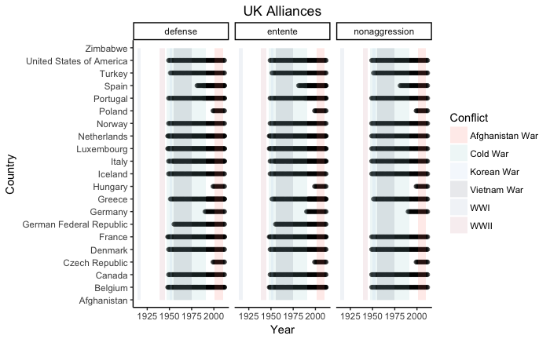

```r
ggplot() +
  xlab("Year") +
  ylab("Country")+
  geom_point(data =al_gb_yr_ongoing, aes(x=year, y = state_name2), alpha = .5) +
  geom_rect(data=d, mapping=aes(xmin=x1, xmax=x2, ymin="Afghanistan", ymax="Zimbabwe", fill=Conflict),alpha=0.15) +
  ggtitle("UK Alliances")+
  theme_classic()+
  theme(legend.position="right", plot.title = element_text(hjust = .5)) +
  scale_fill_manual(values=c("salmon", "paleturquoise3", "lightsteelblue2", "lightsteelblue4", "lightsteelblue3", "pink3")) + facet_wrap(~treaty_type, nrow = 1)+
    facet_wrap(~Treaty, nrow = 1 )
```

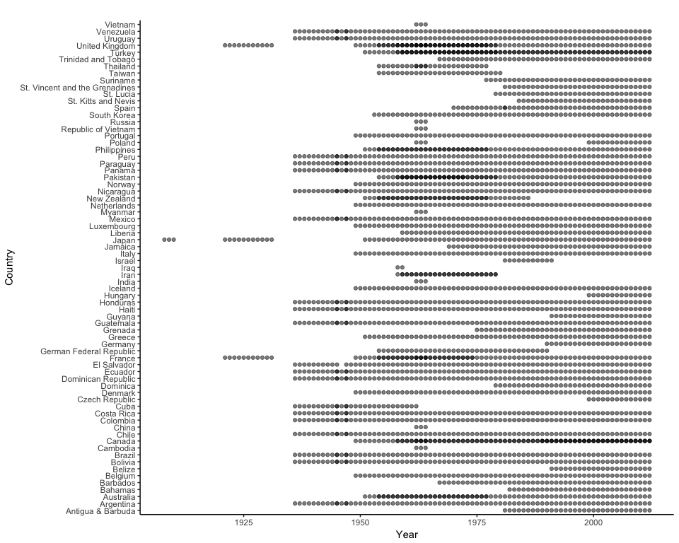

```r
qa <- filter(dir_al_year, dir_al_year$state_name1 %in% c("United States of America"))
qa <- qa[, c(3,5,8,11,18)]
qa$dyad_end_year[qa$dyad_end_year %in% NA] = 2016
#qa <- gather(qa, st_ed, year, dyad_st_year:dyad_end_year )
ggplot() +
  geom_point(data =qa, aes(x=year, y = state_name2), alpha = .5) +
  xlab("Year") +
  ylab("Country")+
  ggtitle("")+
  theme_classic()
```